# Week 5 TA sync session

## 5.0 Agenda

Today, we will cover the below topics:

1. We will see how to find if a function is increasing or decreasing
2. We will find critical numbers for a function
3. Then we will find minima and maxima of a function
4. We will see how to implement the extreme value theorem for a function
5. We will find horizontal asymptotes for a given function
6. We will learn nto apply L'Hopital's rule on a function
7. And finally, we will use Newton's method to arrive at a minima of a given function

## 5.1 Increasing / decreasing function

```python
# import sympy
import sympy as sym
```

```python
#Let us define three functions to test if they are increasing, decreasing or equal between two points

f0 = lambda x: 5
f1 = lambda x: 2*x + 5
f2 = lambda x: -2*x + 5
```

```python
# Now, let us define two values between which we will test each of the above functions
a = 1
b = 4
```

```python
# Let us define functions to find slope of a function to see
#   if any given function is increasing, decreasing or equal between two given points

m = lambda f,a,b: (f(b)-f(a))/(b-a) #ARC

p = lambda f,a,b: [m(f,a,b)>0, m(f,a,b)<0, m(f,a,b)==0]
```

```python
print(*p(f0,a,b))
```

```
False False True
```

```python
print('Testing f0:\n')
print('Increasing? {}, \nDecreasing? {}, \nSame      ? {}'.format(*p(f0,a,b)))
```

```
Testing f0:

Increasing? False,
Decreasing? False,
Same      ? True
```

```python
print('Testing f1:\n')
print('Increasing? {}, \nDecreasing? {}, \nSame      ? {}'.format(*p(f1,a,b)))
```

```
Testing f1:

Increasing? True,
Decreasing? False,
Same      ? False
```

```python
print('Testing f2:\n')
print('Increasing? {}, \nDecreasing? {}, \nSame      ? {}'.format(*p(f2,a,b)))
```

```
Testing f2:

Increasing? False,
Decreasing? True,
Same      ? False
```

## 5.2 Find critical numbers for a function

```python
#Let us definbe an expression
x = sym.symbols('x')
f = (x**3)/3 - (5*x**2)/2 + 6*x - 30
f
```

$\displaystyle \frac{x^{3}}{3} - \frac{5 x^{2}}{2} + 6 x - 30$

```python
#Let us find its derivative function
d = sym.diff(f,x)
d
```

$\displaystyle x^{2} - 5 x + 6$

```python
#Let us solve it to find critical numbers
sym.solve(d,x)
```

```
[2, 3]
```

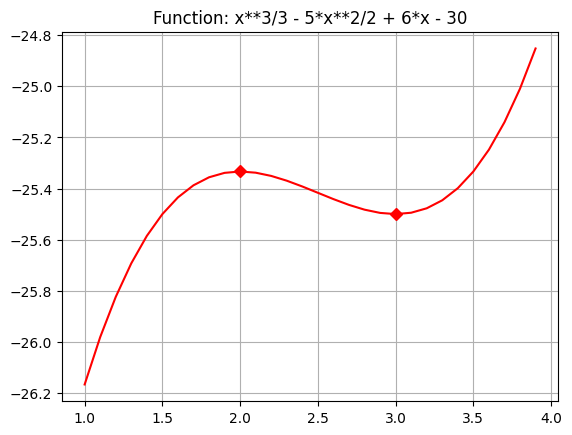

```python
#Let us plot this function

#import essential libraries
import numpy as np
import matplotlib.pyplot as plt

f1 = sym.lambdify(x,f)

#Create a linear series for x values
x1 = np.arange(1,4,0.1)
#print(x1)
mark=[10,20]
#plot the chart of the function except where x = 2
plt.plot(x1, f1(x1), '-rD',markevery=mark)
plt.grid(which='major')
plt.title('Function: {}'.format(f));
plt.show()
```

```python
#Let us look at one more function
x = sym.symbols('x')
f = x**3 + 3*x**2 + 3*x + 1
f
```

$\displaystyle x^{3} + 3 x^{2} + 3 x + 1$

```python
#Let us find its derivative function
d = sym.diff(f,x)
d
```

$\displaystyle 3 x^{2} + 6 x + 3$

```python
#Let us solve it to find critical numbers
sym.solve(d,x)
```

```
[-1]
```

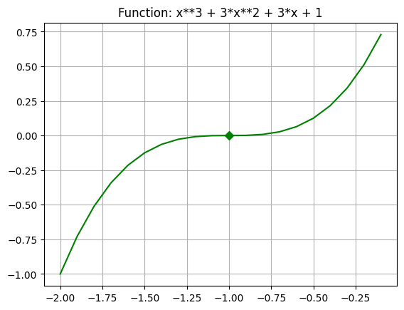

```python
#Let us plot this function

#import essential libraries
import numpy as np
import matplotlib.pyplot as plt

f1 = sym.lambdify(x,f)

#Create a linear series for x values
x1 = np.arange(-2,0,0.1)
mark=[10]
#plot the chart of the function except where x = 2
plt.plot(x1, f1(x1), '-gD',markevery=mark)
plt.grid(which='major')
plt.title('Function: {}'.format(f));
plt.show()
```

## 5.3 Find minima and maxima of a function

```python
#Let us define a function and view it
f = 4*x/(3*x**2+27)
print('The function f:',f)
display(f)

#Let us now find the derivative of that function
d = sym.diff(f,x)
print("\nThe first derivative f\':",d)
display(d)

#Now, let us find roots of the derivative function
roots = sym.solve(d,x)
print('\nRoots of the first derivative:',roots)

#And finally, let us find the double derivative of the above function
dd = sym.diff(d,x)
print("\nThe second derivative f\'\':",dd)
display(dd)
```

```
The function f: 4*x/(3*x**2 + 27)
```

$\displaystyle \frac{4 x}{3 x^{2} + 27}$

```
The first derivative f': -24*x**2/(3*x**2 + 27)**2 + 4/(3*x**2 + 27)
```

$\displaystyle - \frac{24 x^{2}}{\left(3 x^{2} + 27\right)^{2}} + \frac{4}{3 x^{2} + 27}$

```
Roots of the first derivative: [-3, 3]

The second derivative f'': 288*x**3/(3*x**2 + 27)**3 - 72*x/(3*x**2 + 27)**2
```

$\displaystyle \frac{288 x^{3}}{\left(3 x^{2} + 27\right)^{3}} - \frac{72 x}{\left(3 x^{2} + 27\right)^{2}}$

```python
#Let us evaluate above functions at each of the above roots
for root in roots:
    fv  = f.subs({x:root})
    dv  = d.subs({x:root})
    ddv = dd.subs({x:root})
    print('Root value: {}, Expr value: {}, derivative value: {} double derivative value:{}'.format(root,fv,dv,ddv))
```

```
Root value: -3, Expr value: -2/9, derivative value: 0 double derivative value:2/81
Root value: 3, Expr value: 2/9, derivative value: 0 double derivative value:-2/81
```

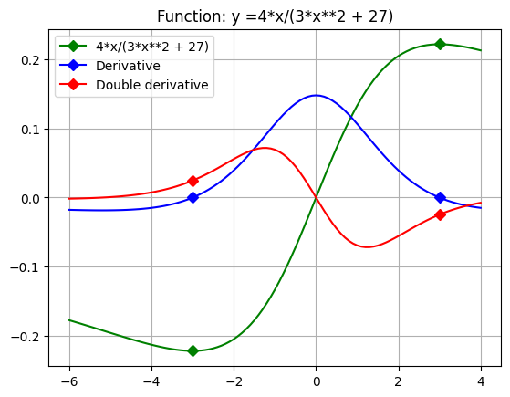

```python
#Let us see this graphically
from sympy.utilities.lambdify import lambdify

#Create functions from earlier expressions
f1 = lambdify(x,f)
d1 = lambdify(x,d)
dd1 = lambdify(x,dd)

#Create a linear series for x values
x1 = np.linspace(-6,4,101)
mark=[30,90]
#plot the chart of the function except where x = 2
plt.plot(x1, f1(x1),'-gD',markevery=mark, label=f)
plt.plot(x1, d1(x1),'-bD',markevery=mark,label='Derivative')
plt.plot(x1,dd1(x1),'-rD',markevery=mark,label='Double derivative')
plt.grid(which='major')
plt.title('Function: y ={}'.format(f));
plt.legend()
plt.show()
```

## 5.4 Extreme value theorem

To find absolute extrema for a function 𝑓 on a closed interval [𝑎,𝑏]:

- Find all critical numbers for 𝑓 in (𝑎,𝑏)
- Evaluate 𝑓 for all critical numbers in (𝑎,𝑏)
- Evaluate 𝑓 at the end points 𝑎 and 𝑏
- The largest value found in step 2 or 3 is the absolute maximum for 𝑓 on [𝑎,𝑏] and the smallest value found is the absolute minimum for 𝑓 on [𝑎,𝑏]

```python
#Define symbol
x = sym.symbols('x')

#Define expression
f = x**3 + 3*x**2 - 9*x + 4

#Define end-points
a,b = -6,5

print('Original expression is:')
display(f)

#Find derivative of the expression
df = sym.diff(f,x)

print('Derivative of the expression is:')
display(df)

#Find double derivative of the expression
ddf = sym.diff(df,x)

print('Double derivative of the expression is:')
display(ddf)

#Find roots of the derivative
r = sym.solve(df,x)
print('Roots of the Derivative is:',r)

#Add points a & b
r.insert(0,a)
r.append(b)
print('\nValues at which we need to evaluate the function:',r)

F = np.array([f.subs(x,a) for a in r])
print('\n\nValue of the expression at all the points:',F)
```

```
Original expression is:
```

$\displaystyle x^{3} + 3 x^{2} - 9 x + 4$

```
Derivative of the expression is:
```

$\displaystyle 3 x^{2} + 6 x - 9$

```
Double derivative of the expression is:
```

$\displaystyle 6 x + 6$

```
Roots of the Derivative is: [-3, 1]

Values at which we need to evaluate the function: [-6, -3, 1, 5]


Value of the expression at all the points: [-50 31 -1 159]
```

```python
#Let us see this graphically
from sympy.utilities.lambdify import lambdify

#Create functions from earlier expressions
f1 = lambdify(x,f)
d1 = lambdify(x,df)

#Create a linear series for x values
x1 = np.linspace(-6,5,101)
mark = [0,27,64,100]
#plot the chart of the function except where x = 2
plt.plot(x1, f1(x1),'-gD', markevery=mark, label=f)
plt.plot(x1, d1(x1),'-bD', markevery=mark, label=df)
plt.grid(which='major')
plt.title('Function: y ={}'.format(f));
plt.legend()
plt.show()
```

[output not shown]

### 5.4.1 Use of exponential function

```python
#Define symbol
x = sym.symbols('x')

#Define expression
f = x**2*10**-x

#Define end-points
a,b = -6,5

print('Original expression is:')
display(f)

#Find derivative of the expression
df = 10**-x*x*(2-x)

print('Derivative of the expression is:')
display(df)

#Find double derivative of the expression
ddf = 2*10**-x*(x-2)**2

print('Double derivative of the expression is:')
display(ddf)

#Find routes of the derivative
r = sym.solve(df,x)
print('Roots of the Derivative is:',r)

#Add points a & b
r.insert(0,a)
r.append(b)
print('\nValues at which we need to evaluate the function:',r)

F = np.array([f.subs(x,a) for a in r])
print('\n\nValue of the expression at all the points:',F)
```

[output not shown]

```python
#Let us see this graphically
from sympy.utilities.lambdify import lambdify

#Create functions from earlier expressions
f1 = lambdify(x,f)
d1 = lambdify(x,df)

#Create a linear series for x values
x1 = np.linspace(-6,4,101)
mark = [0, 60, 80, 100]
#plot the chart of the function except where x = 2
plt.plot(x1, f1(x1), '-gD', markevery=mark, label='x**2*np.e**-x')
plt.plot(x1, d1(x1),label='derivative function')
plt.grid(which='major')
plt.title('Function: y ={}'.format(f));
plt.legend()
plt.show()
```

[output not shown]

## 5.5 Horizontal asymptotes

The value of y=L where L is the value of function at x = +oo and -oo.

(We also have vertical and oblique asymptotes for some function)

```python
# Let us find horizontal asymptotes of a given function
x = sym.symbols('x')
f = (2*x**2 + 1)/x**2

print('The given expression :')
display(f)

# Let us simplify the given expression
f = sym.simplify(f)

print('The simplified expression :')
display(f)

#Find and print the horizontal asymptotes
pha = sym.limit(f,x,sym.oo)
nha = sym.limit(f,x,-sym.oo)

print('The horizontal asymtots of the function at +oo is {} and -oo is {}'.format(pha,nha))
```

```
The given expression :
```

$\displaystyle \frac{2 x^{2} + 1}{x^{2}}$

```
The simplified expression :
```

$\displaystyle 2 + \frac{1}{x^{2}}$

```
The horizontal asymtots of the function at +oo is 2 and -oo is 2
```

```
X: [-1000000000  -100000000   -10000000    -1000000     -100000      -10000
       -1000        -100         -10           1          10         100
        1000       10000      100000     1000000    10000000   100000000
  1000000000]
Y: [2.         2.         2.         2.         2.         2.00000001
 2.000001   2.0001     2.01       3.         2.01       2.0001
 2.000001   2.00000001 2.         2.         2.         2.
 2.        ]
```

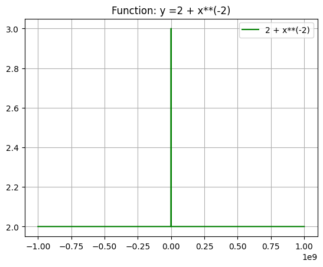

```python
#Let us see this graphically
from sympy.utilities.lambdify import lambdify

#Create functions from earlier expressions
f1 = lambdify(x,f)

#Create a linear series for x values
x1 = 10**(np.arange(10))
x1 = np.append(-x1[-np.arange(1,10)],x1)
y1 = f1(x1)
print("X:",x1)
print("Y:",y1)

#plot the chart of the function except where x = 2
plt.plot(x1, y1,'-g', label=f)
#plt.xscale('log')  # Set x-axis to log scale
plt.grid(which='major')
plt.title('Function: y ={}'.format(f));
plt.legend()
plt.show()
```

## 5.6 L'Hopital's rule

```python
#When we have a situation of 0/0 or oo/oo while finding limit of a function, we use this rule

x = sym.symbols('x')
fn = sym.ln(x)
fd = (x-1)
f  = fn/fd
display(f)
```

$\displaystyle \frac{\log{\left(x \right)}}{x - 1}$

```python
f.subs({x:1})
```

$\displaystyle \text{NaN}$

```python
sym.limit(f,x,1)
```

$\displaystyle 1$

```python
sym.diff(fn)
```

$\displaystyle \frac{1}{x}$

```python
sym.diff(fd)
```

$\displaystyle 1$

```python
dfn = 1/x
dfd = 1
df  = dfn/dfd
df
```

$\displaystyle \frac{1}{x}$

```python
df.subs({x:1})
```

$\displaystyle 1$

```python
sym.limit(df,x,1)
```

[output not shown]

```python
fn = x+1
fd = x+2
f = fn/fd
f
```

$\displaystyle \frac{x + 1}{x + 2}$

```python
f.subs({x:3})
```

$\displaystyle \frac{4}{5}$

## 5.7 Newton’s method

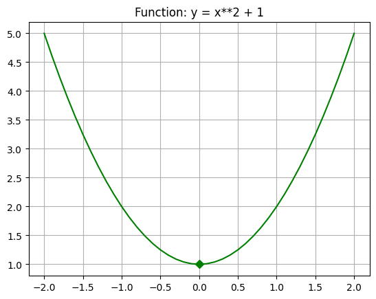

```python
#Create a linear series for x values
x = np.arange(-2,2.1,0.1)

#Create a function f
f = lambda x: x**2 + 1
mark = [20]
#plot the chart of the function
plt.plot(x, f(x),'-gD', markevery=mark)
plt.grid(which='major')
plt.title('Function: y = x**2 + 1');
plt.show()
```

```python
#let us look at the example of gradient descent mechanism based on Newton's method

# import mpmath library package
import mpmath as mp

#Let us define a starting value and and find the value of function f(x) at the starting value
x0 = 10
print(x0,f(x0))
```

```
10 101
```

```python
# Now, let us define a gradient descent function based on Newton’s method
f1 = lambda x0,f: x0 - f(x0)/mp.diff(f,x0)
```

```python
# Now, let us start and keep applying this on the starting point and on each of the new point found
x0 = f1(x0,f)
print(x0,f(x0))
```

```
4.95 25.5025
```

```python
x0 = f1(x0,f)
print(x0,f(x0))
```

```
2.3739898989899 6.63582804050607
```

```python
x0 = f1(x0,f)
print(x0,f(x0))
```

```
0.976379057568559 1.95331606405847
```

```python
x0 = f1(x0,f)
print(x0,f(x0))
```

```
-0.0239066659509208 1.00057152867689
```

```python
x0 = 100
X,Y = [],[]
for i in range(12):
    X.append(x0)
    Y.append(f(x0))
    print(x0,f(x0))
    x0 = f1(x0,f)
```

```
100 10001
49.995 2500.500025
24.9874989999 625.375106270003
12.4737394941466 156.594176967833
6.19678553654168 39.4001509858922
3.01770577385227 10.1065481375413
1.34316410297232 2.80408980751343
0.299326718803027 1.08959648458939
-1.52075217182618 3.31268716811403
-0.431591416548071 1.18627115083797
0.942707405617964 1.88869725260695
-0.0590335594744191 1.00348496114422
```

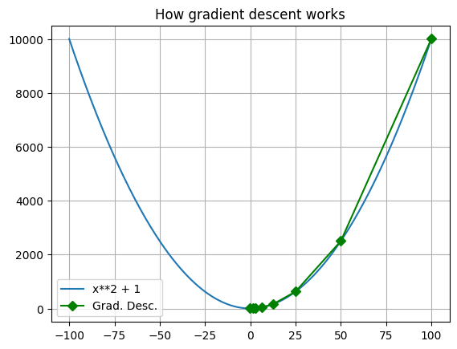

```python
#plot the chart of the function
x = np.arange(-100,100)
y = f(x)
mark=[0,1,2,3,4,5,6, 11]
plt.plot(x, y, label='x**2 + 1')
plt.plot(X, Y, '-gD', markevery=mark, label='Grad. Desc.')
plt.grid(which='major')
plt.title('How gradient descent works');
plt.legend()
plt.show()
```

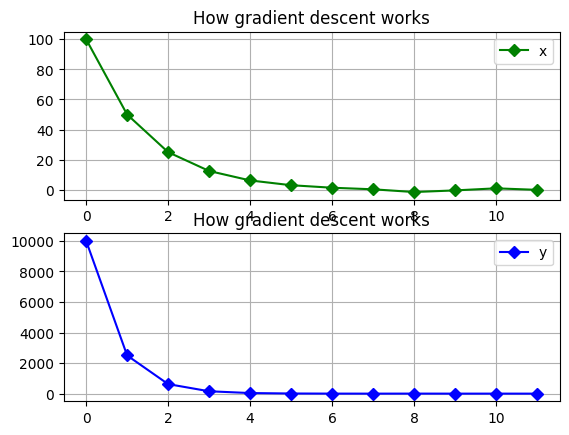

```python
i = np.arange(0,12,1)

plt.subplot(2,1,1)
plt.plot(i, X,'-gD', markevery=i, label='x')
plt.grid(which='major')
plt.title('How gradient descent works');
plt.legend()

plt.subplot(2,1,2)
plt.plot(i, Y,'-bD', markevery=i, label='y')
plt.grid(which='major')
plt.title('How gradient descent works');
plt.legend()
plt.show()
```

## 5.8 Summary & conclusion

Today we learned the below:

- Finding an increasing or decreasing function
- Finding critical numbers for a function
- Finding minima and maxima of a function
- Implementing the extreme value theorem for a function
- Finding horizontal asymptotes for a given function
- Applying L'Hopital's rule on a function
- Using Newton's method to arrive at a minima of a given function